[figure not shown]

# Homework 2: Social Networks in R

## I. Getting Ready:

- Set seed

```r
set.seed(1111)
```

### II. Network Creation from dataframes

```r
## link to file on GitHub
fileLink='https://raw.githubusercontent.com/DACSS-CSSmethods-w26/Homework_2/refs/heads/main/docs/hollywood.graphml'

library(igraph) # package needed
#read in the graph file
actors=read_graph(fileLink,format='graphml')
```

## III. Exploration of Network nodes

Let’s compute measures for each node, and save them into a data frame:

```r
#compute eigenvector
eigen=eigen_centrality(actors)$vector

#compute closeness
close=closeness(actors,normalized=T)

#compute betweeness
betw=betweenness(actors,normalized=T)

#create a centrality dataset
DFCentrality=as.data.frame(cbind(eigen,close,betw),stringsAsFactors = F)
names(DFCentrality)=c('Eigenvector','Closeness','Betweenness')

DFCentrality$person=row.names(DFCentrality)
row.names(DFCentrality)=NULL
DFCentrality
```

```
##    Eigenvector Closeness Betweenness            person
## 1  0.606705039 0.3571429  0.37777778    Robin Williams
## 2  0.014699527 0.3703704  0.01111111         Tom Hardy
## 3  0.034689773 0.4545455  0.17777778    Dustin Hoffman
## 4  0.037143649 0.4761905  0.33333333 Leonardo DiCaprio
## 5  0.072098921 0.5000000  0.53333333         Tom Hanks
## 6  1.000000000 0.2702703  0.00000000         Al Pacino
## 7  0.007860685 0.3125000  0.02222222    Morgan Freeman
## 8  1.000000000 0.2702703  0.00000000    Robert De Niro
## 9  0.188206119 0.4347826  0.46666667        Matt Damon
## 10 0.012477963 0.3703704  0.07777778    Jack Nicholson
## 11 0.015873210 0.3846154  0.11111111    Christian Bale
```

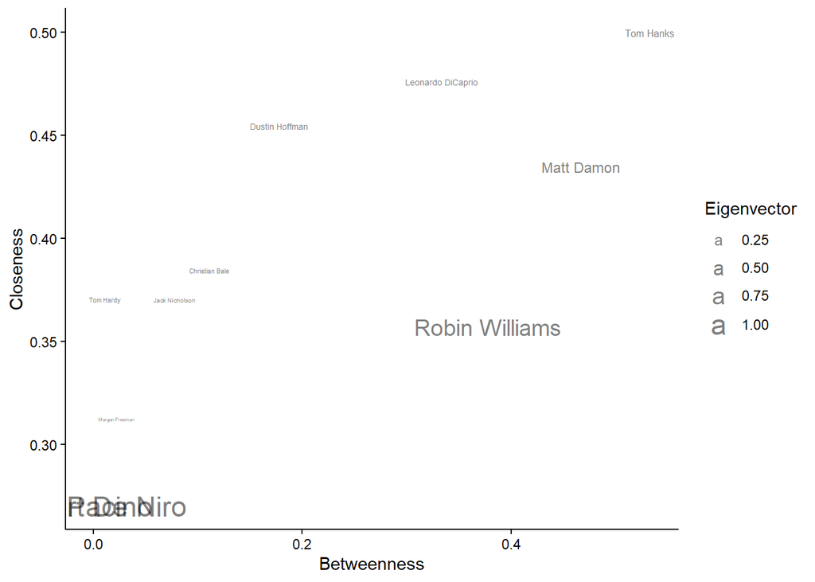

```r
library(ggplot2) #needed library

#create the correlation plot
ggplot(DFCentrality, aes(x=Betweenness, y=Closeness)) +
    theme_classic() +
    geom_text(aes(label=person,size=Eigenvector),show.legend = T,alpha=0.5)
```

- Al Pacino and Robert De Niro have the highest eigenvectors, so they are they most influential (they are connected to vertices that are also well connected).
- Tom Hanks has the highest closeness, so he can share information faster than the rest.
- Tom Hanks and Matt Damon have the highest betweenness, indicating that they are important to connect vertices that are not connected directly.

## IV. Communities

### IV.1 **Potential Communities?**

1. Computing a random network:

```r
#create a random network
RandomNet <- sample_gnp(length(V(actors)),p=edge_density(actors))
```

2. Get Transitivity rate

```r
#get the transitivity rate
transitivity(actors)/transitivity(RandomNet)
```

```
## [1] 0.875
```

The above code shows that the transitivity of the actors network divided by the transitivity of a random network is less than 1. Therefore, there is not evidence that there are potential communities.

### 5.2 **Two approaches**

1. Girvan-Newman:

The **girvan_newman** algorithm is based on creating partitions using the centrality of nodes to create partition too. We can create something similar to the last result like this:

```r
# Membership vector will be selected based
# on the highest modularity score
partition_girvanNewman_best <- cluster_edge_betweenness(actors)
```

The modularity:

```r
#calculate the max modularity
max(partition_girvanNewman_best$modularity)
```

```
## [1] 0.4199219
```

2. Louvain:

```r
#calculate communities based on the louvain algorithm (bottom-up method)
partition_louvain_optimal <- cluster_louvain(actors)
```

The modularity:

```r
#calculate the max modularity
max(partition_louvain_optimal$modularity)
```

```
## [1] 0.4121094
```

### 5.3 **Plotting communities**

First, creating new columns:

```r
#since Girvan-Newman has a higher modularity, add it to the dataset for plotting
V(actors)$girvanNewman=as.factor(membership(partition_girvanNewman_best))
```

Now plot the one with the best modularity (Girvan-Newman):

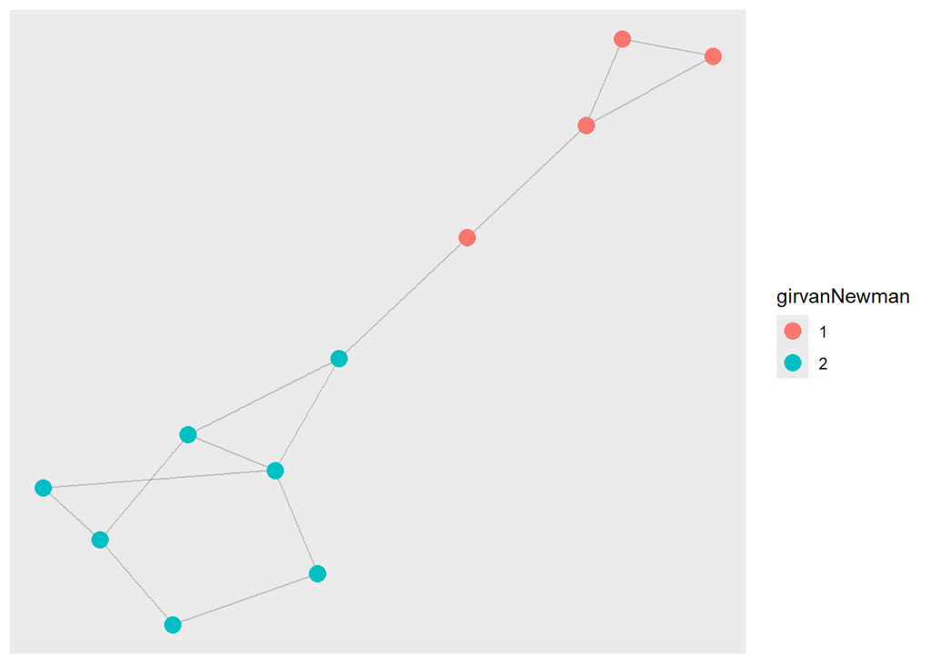

```r
library(ggraph)
#graph the Girvan-Newman communities
base=ggraph(graph =actors,layout = 'fr') + geom_edge_link(alpha=0.2)
base + geom_node_point(aes(color=girvanNewman), show.legend = T, size=4)
```